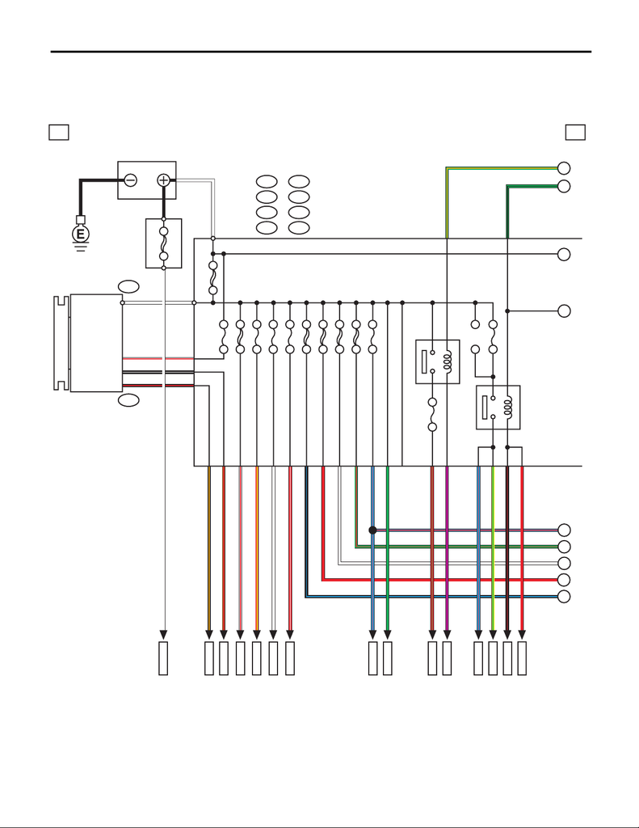

WI-28

Power Supply Circuit

WIRING SYSTEM

4. Power Supply Circuit

A: WIRING DIAGRAM

1. ENGINE TYPE FA (WITHOUT PUSH BUTTON START)

WI-44246

1a 1a

F26

F25

W

W

Y/G

BR/R

B/O

B/R

W/R

B/W

2

1

B/R3

B1

B7

C10

B

A

C

I

H

D

A7

A9

A19

L/R E5

E6

R/G G7

H8

G/O

G/B

H4

B19

G

F

E

B143

B:

F36

E:

B571

F:

B186

H:

M/B

F37

A:

F35

C:

B144

D:

B145

G:

L/R D9

GF2

G/R D3

WD2

RD6

R/W E3

R/Y D5

W/R D7

B11

B/L D8

R

V

G/O

G/B

L/R

G/R

W

R

B/L

WD1

MB-3

W

BAT-1

MB-5

MB-6

MB-7

MB-8

MB-9

MB-1

MB-33

MB-4

MB-10

MB-2

ALT-2

ALT-1

MB-29

SBF-2 50A

SBF-3 50A

SBF-6 40A

SBF-8 50A

SBF-1 40A

B

80A

No. 4

No. 10 25A

No. 16 7.5A

No. 1 30A

No. 5 25A

No. 3 25A

No. 8 20A

No. 2 25A

MAIN SBF 120A

REAR DEFOGGER RELAY

MAIN FAN RELAY 1

BATTERY

GENERATOR

SLOW

BLOW

FUSE

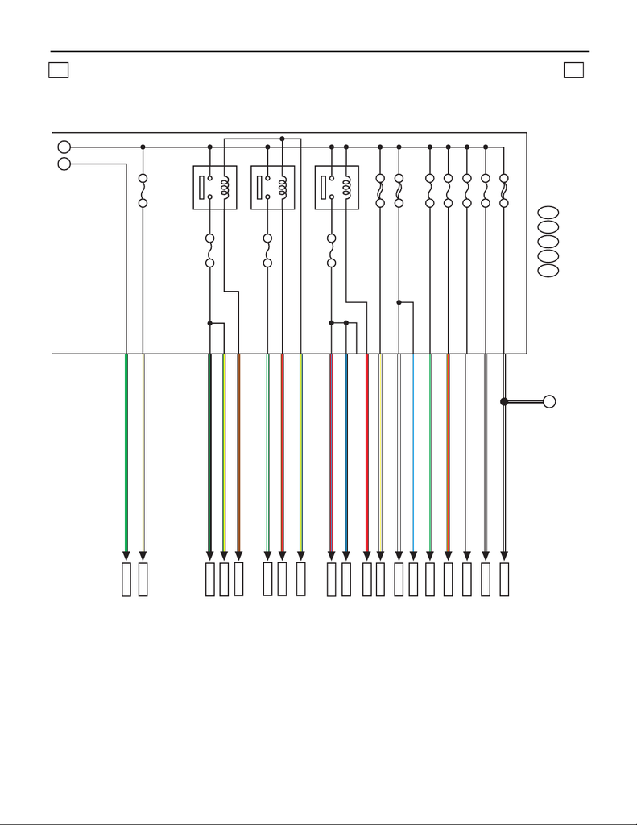

WI-29

Power Supply Circuit

WIRING SYSTEM

WI-44247

1b 1b

B143

F35

F36

B145

B186

W/B H6

WH5

G4

M/B

B/W

W/G H3

W/L G6

W/Y G1

G5W/R

B:

C:

E:

G:

H:

RH1

C9

C8

B16

G/W E1

G/Y E4

B18

W/Y G2

C11

C

D

J

G

BR/R

B15L/Y

BR

R/L

B/L

B/W

Y/R H7

SBF-4 30A

SBF-5 30A

MB-26

MB-13

MB-30

MB-12

MB-19

MB-16

MB-17

MB-18

MB-23

MB-20

MB-28

MB-32

B/G B8

MB-15

MB-27

MB-24

MB-25

MB-22

MB-11

MB-21

SBF-7 30A

No. 9 15A

No. 7 15A

No. 6 30A

No. 15 15A

No. 11 15A

No. 12 20A

No. 13 7.5A

No. 14 15A

HORN RELAY

HEADLIGHT RELAY HI

HEADLIGHT RELAY LO

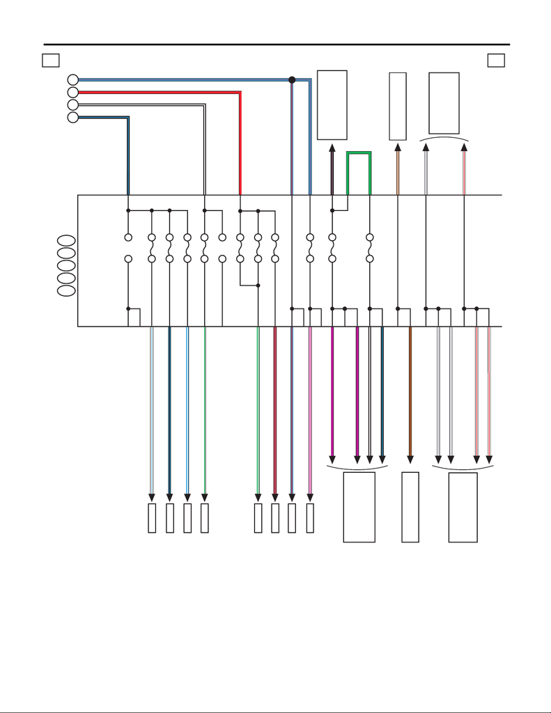

WI-30

Power Supply Circuit

WIRING SYSTEM

WI-44248

1c 1c

B/W

B12

C17

B/L

V

V

A11

C5

R/L C2

G/W

F1

B/L

B/W

E6

E4

R

F6

G

C20

C21

E7

E2

W/G

A9

L/W

C15

L/B

E3

W/L

E1

E

H

J

I

F/B

i5

A:

R168

B:

B52

C:

B158

E:

B159

F:

G

L/R

L/R

C4

B/P

B15

BR

BR/W

F9

A12

GR

GR

C18

B3

GR

A18

W/R

A4

L/R

B2

P

W/R

C9

L/R

R

B/W

B/L

B20

W/R

FB-3

FB-9

FB-10

FB-11

FB-8

FB-6

FB-5

FB-4

REF. TO TURN SIGNAL

LIGHT & HAZARD LIGHT

SYSTEM [b]

REF. TO CLEARANCE

LIGHT & ILLUMINATION

LIGHT SYSTEM [1a]

REF. TO STOP LIGHT

SYSTEM [1a]

REF. TO

TURN SIGNAL LIGHT

& HAZARD LIGHT

SYSTEM [b]

REF. TO STOP LIGHT

SYSTEM [1a]

REF. TO CLEARANCE

LIGHT & ILLUMINATION

LIGHT SYSTEM [1a]

No. 15 10A

No. 14 10A

No. 16 7.5A

No. 17 15A

No. 29 15A

No. 28 15A

No. 27 15A

No. 10

No. 9 7.5A

No. 8 7.5A

No. 1

No. 3 15A

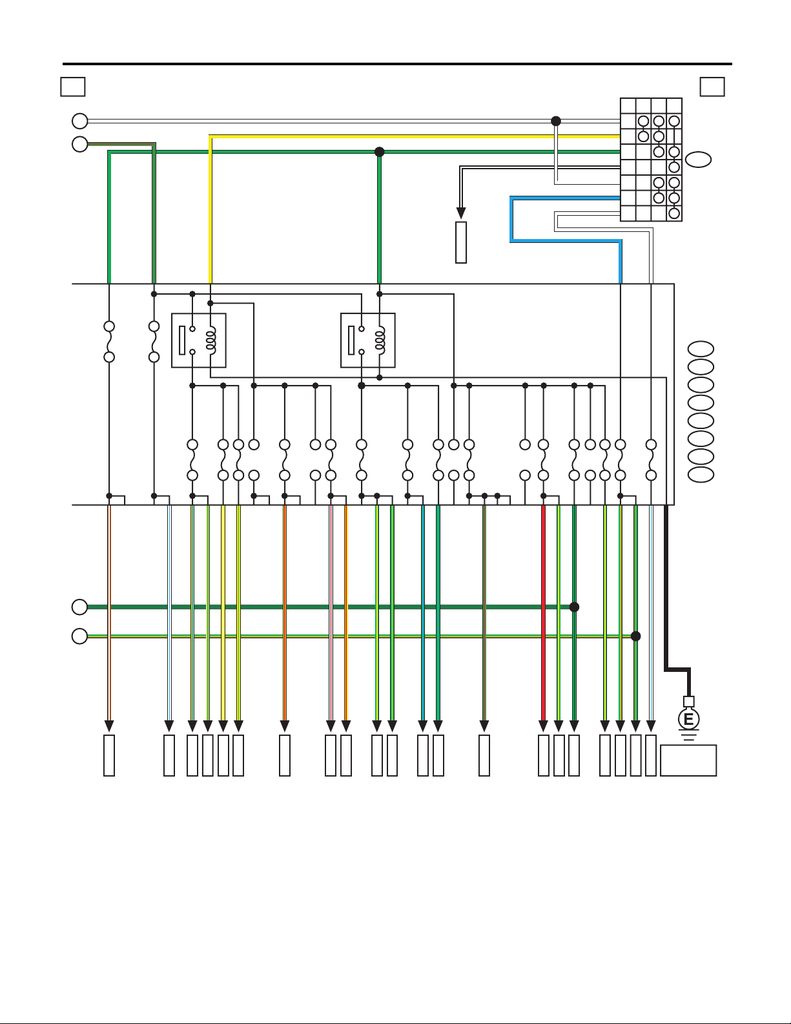

WI-31

Power Supply Circuit

WIRING SYSTEM

WI-44249

B72

B

1d 1d

G/R

Y

E5

F7

GF8

GE8

F3

A19

A7

W/L C19

G

F

A

F/B

i5

A:

R168

B:

B52

C:

B152

D:

B158

E:

B159

F:

B162

G:

L

F2 W

G/B C11

G2G/Y

W/L D1

G/O

G/O

A3

D8

G/Y D3

C1

D6

BR/W

Y/G

A17Y/R

A1GR/R

D7Y/R

Y/W B14

Y/L

G/Y

C8

G/L D9

C16G/L

G/R C24

B

4

2

1

W

L

W

3

5

6

7

ACCOFF

ON ST

W

B/W

Y

G

B

G/B

G/O

G/R

W

H2R

G/Y

B18

AB35

H:

FB-31

FB-47

FB-35

FB-34

FB-29

FB-25

FB-20

A10Y/L

FB-19

FB-46

FB-44

FB-42

FB-41

FB-22

FB-21

FB-12

ST-2

FB-38

FB-32

FB-28

ST-1

FB-45

FB-18

No. 19

No. 32

No. 6 7.5A

No. 13 20A

No. 21 7.5A

No. 22 10A

No. 33 7.5A

No. 26 7.5A

No. 25 15A

No. 12 15A

No. 5

No. 18 10A

No. 11 7.5A

No. 4 10A

No. 31 7.5A

No. 30

No. 24 10A

No. 23

No. 20 10A

No. 7 10A

No. 2 7.5A

REF. TO GND

[b]

IG 2 RELAY

ACCESSORY RELAY

IGNITION SWITCH

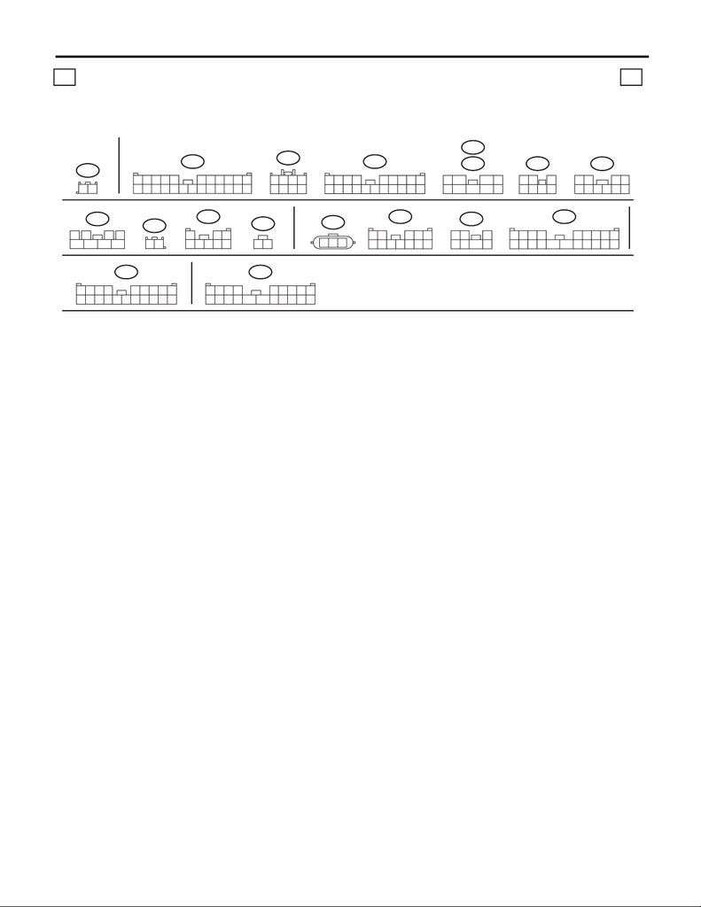

WI-32

Power Supply Circuit

WIRING SYSTEM

AB35

A:

F37

B143

B571

G:

B:

B158

E:

H:

F26

B152

(B)

B186H:

F:

G:

B159F:

(BR)

B144D:

F36E:

(BR)

B145

(L)

F35C:

B52C:

D:

(GR)

B162

WI-44250

1e 1e

12

3412 89

10 11

12 13 14 15 16 17 18 19 20 21 22 23 24

567

89

19 20

1234 567

10 11 12 13 14 15 16 17 18

i5

A:

89

19 20

1234 567

10 11 12 13 14 15 16 17 18

1

5

76

2

8

34

9

12 3

45

6

7

8765

21

10

9

43

1

7856

234

12

123

45678

21

123

12

3

45

6789

10 11 12

12 3

4567

1234

56789

10 11 12 13 14 15 16 17 18 19 20

B:

R168

1234

56789

10 11 12 13 14 15 16 17 18 19 20

B72

7856

341

2

LIST OF CONNECTORS

[figure not shown]

WI-33

Power Supply Circuit

WIRING SYSTEM

No. Load

MB-1 VDC CM

MB-2 VDC CM

MB-3 Audio amplifier

MB-4 Sub fan relay

MB-5 Mirror heater LH

Mirror heater RH

Rear defogger

MB-6 Body integrated unit

MB-7 Main fan relay 2

MB-8 Main fan motor

MB-9 ECM

MB-10 Main fan relay 2

MB-11 Main fan relay 2

MB-12 Body integrated unit

MB-13 Body integrated unit

MB-15 Front fog light relay

MB-16 Front combination light LH

Front combination light RH

MB-17 Daytime running light relay

MB-18 Body integrated unit

MB-19 Horn

MB-20 Horn

MB-21 Horn switch

Body integrated unit

MB-22 A/F, oxygen sensor relay

Fuel injector relay

MB-23 Main relay

IG relay

MB-24 Electronic throttle control relay

MB-25 Fuel pump relay

MB-26 TCM

Self shut relay

MB-27 ECM

Data link connector

Battery sensor

MB-28 Turn signal and hazard unit

Body integrated unit

Key warning switch

MB-29 Body integrated unit

Immobilizer antenna

Room light

Overhead console (spot map light)

Stereo camera cover (spot map light)

MB-30 Power window circuit breaker

MB-32 Tail & Illumination relay

Daytime running light relay

MB-33 Wiper relay

Brake pump relay

ALT-2 ECM

ST-1 Clutch start switch

Starter relay 1

ST-2 Starter relay 1

FB-3 Stop light and brake switch

FB-4 Wiper deicer relay

FB-5 Seat heater relay

FB-6 Body integrated unit

FB-8 Blower motor relay

FB-9 Front fog light relay

FB-10 Navigation unit

MFD

Audio

FB-11 Trunk room light

TPMS & keyless entry CM

Keyless entry CM

FB-12 MFD

Combination meter

FB-18 Security CM

Combination meter

Impact sensor

Air mix door actuator LH

Air mix door actuator RH

Mode door actuator

Body integrated unit

FB-19 Remote control mirror switch

FB-20 Seat heater relay

Rear view mirror

FB-21 Rear accessory power supply socket

FB-22 Front accessory power supply socket

FB-25 Audio

Navigation unit

FB-28 A/C control panel

FB-29 Body integrated unit

FB-31 TPMS & keyless entry CM

FB-32 Sunroof switch

Clutch switch

Sunroof unit

Data link connector

Stop light and brake switch

Wiper deicer relay

Impact sensor

FB-34 Turn signal and hazard unit

FB-35 Inhibitor switch

Back-up light switch

Auto headlight beam leveler CM

FB-38 ECM

TCM

Body integrated unit

Fuel pump relay

Keyless access CM

No. Load

[figure not shown]

WI-34

Power Supply Circuit

WIRING SYSTEM

FB-41 Airbag CM

FB-42 Power window relay

Wiper relay

FB-44 VDC CM

Steering angle sensor

Power steering CM

FB-45 A/C control panel

FB-46 A/C relay

Sub fan relay

Pressure switch

Blower motor relay

FB-47 Occupant detection control module

BAT-1 Power steering CM

No. Load

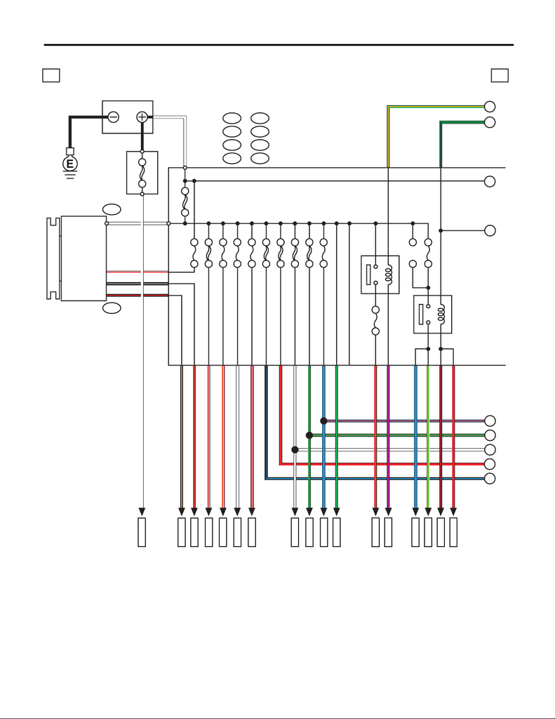

WI-35

Power Supply Circuit

WIRING SYSTEM

2. ENGINE TYPE FA (WITH PUSH BUTTON START)

WI-44251

2a 2a

F26

F25

W

B

W

Y/G

BR/R

B/O

B/R

W/R

B/W

2

1

B/R3

B1

B7

C10

B

A

C

I

H

D

A7

A9

A19

L/R E5

E6

R/G G7

H8

G/O

G/B

H4

B19

G

F

E

B143

B:

F36

E:

B571

F:

B186

H:

M/B

F37

A:

F35

C:

B144

D:

B145

G:

L/R D9

GF2

G/R D3

WD2

RD6

R/W E3

R/Y D5

W/R D7

B11

B/L D8

R

V

G/O

G/B

L/R

G/R

W

R

B/L

WD1

SBF-2 50A

SBF-3 50A

SBF-6 40A

SBF-8 50A

SBF-1 40A

MB-35

ALT-2

ALT-1

MB-29

MB-31

MB-3

MB-5

MB-6

MB-7

MB-8

MB-9

MB-1

MB-33

MB-4

MB-10

MB-2

W

BAT-1

80A

SLOW

BLOW

FUSE

No. 4

No. 2 25A

No. 16 7.5A

No. 1 30A

No. 5 25A

No. 3 25A

No. 8 20A

No. 10 25A

REAR DEFOGGER RELAY

MAIN FAN RELAY 1

BATTERY

GENERATOR

MAIN SBF 120A

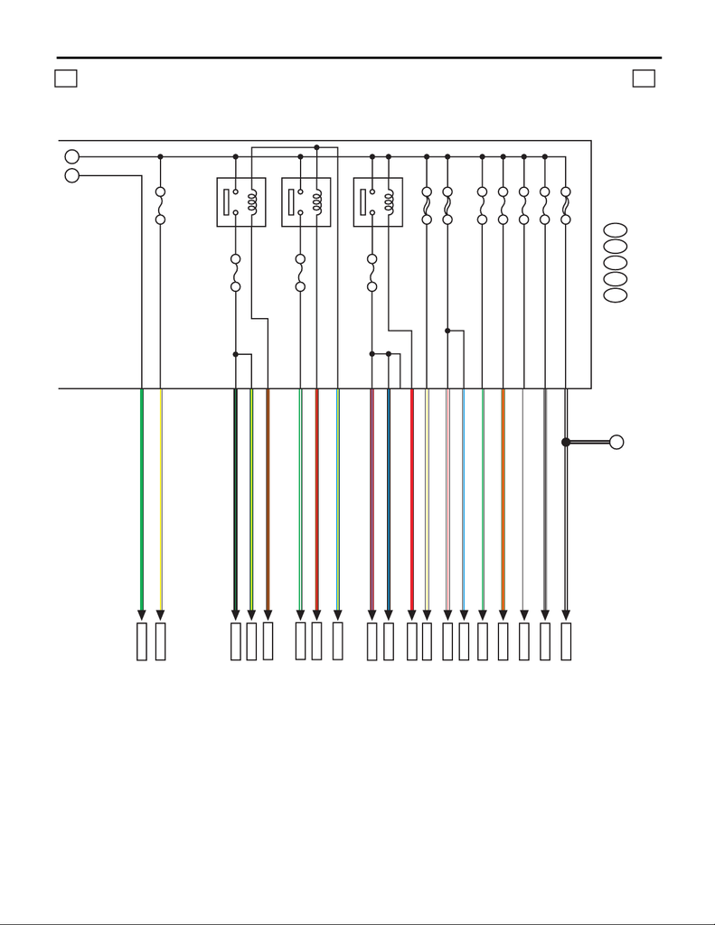

WI-36

Power Supply Circuit

WIRING SYSTEM

WI-44252

2b 2b

B143

F35

F36

B145

B186

W/B H6

WH5

G4

M/B

B/W

W/G H3

W/L G6

W/Y G1

G5W/R

B:

C:

E:

G:

H:

RH1

C9

C8

B16

G/W E1

G/Y E4

B18

W/Y G2

C11

C

D

J

G

BR/R

B15L/Y

BR

R/L

B/L

B/W

Y/R H7

SBF-5 30A

SBF-7 30A

MB-26

MB-13

MB-30

MB-12

MB-19

MB-16

B/G B8

MB-15

MB-17

MB-18

MB-23

MB-20

MB-28

MB-32

MB-27

MB-24

MB-25

MB-22

MB-11

MB-21

SBF-4 30A

No. 11 15A

No. 12 20A

No. 13 7.5A

No. 14 15A

No. 15 15A

No. 9 15A

No. 7 15A

No. 6 30A

HORN RELAY

HEADLIGHT RELAY HI

HEADLIGHT RELAY LO

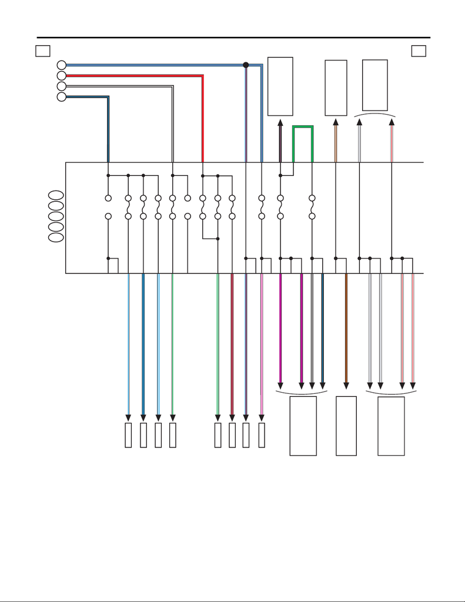

WI-37

Power Supply Circuit

WIRING SYSTEM

WI-44253

2c 2c

B/W

B12

C17

B/L

V

V

A11

C5

R/L C2

G/W

F1

B/L

B/W

E6

E4

R

F6

G

C20

C21

E7

W/G

A9

L/W

C15

L/B

E3

W/L

E1

E

H

J

I

F/B

i5

A:

R168

B:

B52

C:

B158

E:

B159

F:

G

L/R

C4

B/P

E2

L/R

B15

BR

BR/W

F9

A12

GR

GR

C18

B3

GR

A18

W/R

A4

L/R

W/R

C9

L/R

R

B/W

B/L

B2

P

B20

W/R

FB-11

FB-10

FB-9

FB-8

FB-6

FB-5

FB-4

FB-3

REF. TO

TURN SIGNAL LIGHT

& HAZARD LIGHT

SYSTEM [b]

No. 15 10A

No. 14 10A

No. 16 7.5A

No. 17 15A

No. 29 15A

No. 28 15A

No. 27 15A

No. 10

No. 9 7.5A

No. 8 7.5A

No. 1

No. 3 15A

REF. TO TURN SIGNAL

LIGHT & HAZARD LIGHT

SYSTEM [b]

REF. TO STOP LIGHT

SYSTEM [1a]

REF. TO CLEARANCE

LIGHT & ILLUMINATION

LIGHT SYSTEM [1a]

REF. TO CLEARANCE

LIGHT & ILLUMINATION

LIGHT SYSTEM [1a]

REF. TO STOP LIGHT

SYSTEM [1a]

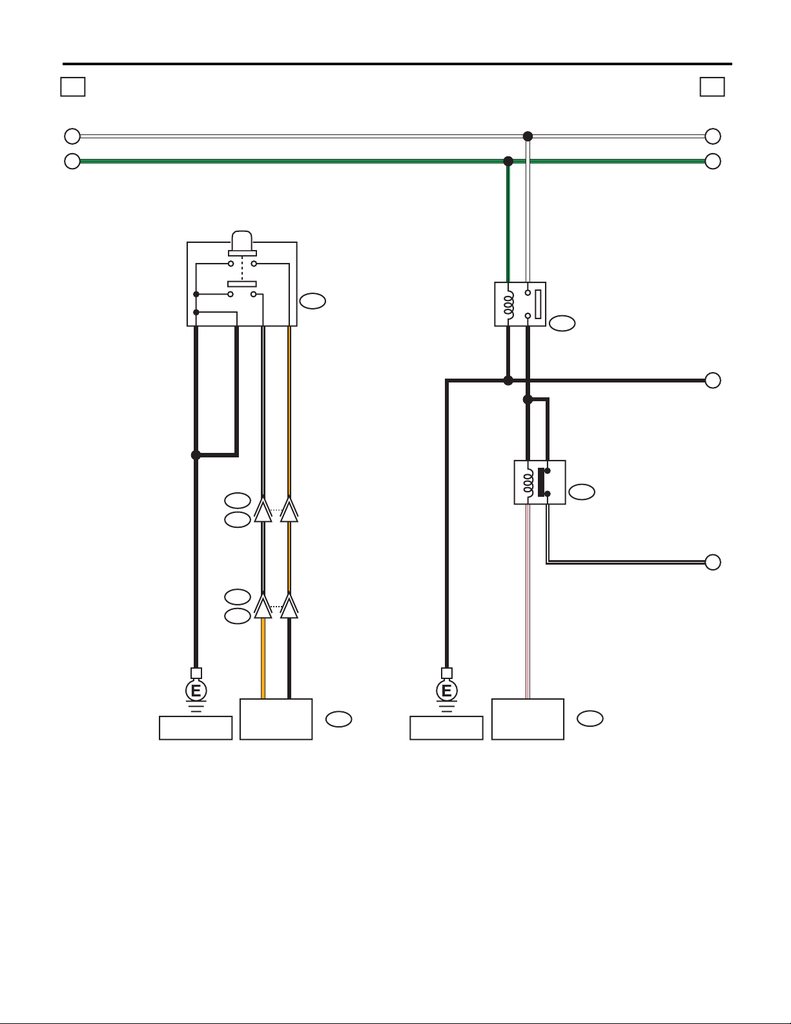

WI-38

Power Supply Circuit

WIRING SYSTEM

B

B

B225

B225

WI-44254

i150

20

19

2d 2d

W

W

G

K

G/B

G/B

B

L

N

B

B/W

M

G/B30

W29

B42

B44

31B

2B/O

7B/W

4B

5B

28B40W/R

41B/W

BC30

OC28

A13

B134A:

W/R

B553

i231

16

17

B576

B575

B574

C:

B/O

B/O

B/W

B/W

ECM

REF. TO GND

[b] [d]

KEYLESS ACCESS CM

REF. TO GND

[e]

PUSH BUTTON

IGNITION SWITCH

STARTER CUT

RELAY

STARTER RELAY

(PUSH BUTTON START)

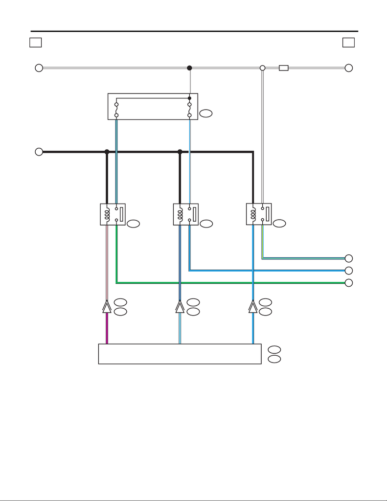

WI-39

Power Supply Circuit

WIRING SYSTEM

B225B225

B426

WI-44255

3

11

5

20A

B550

2e 2e

W

K

B

M

L/Y

P

O

B35

W/L32

34L/R

L

23L/O

24W/L

33

B39

L/O37

38GR/R

36G

B2

W3

1L

L/R

GR/R

L

4L/Y

Q

G

L

R

B572

A:

B574

C:

L

SB

V

C4

A9

C6

B28

B23

B576

B575

B28

B23

15A

W

W

9

MT

KEYLESS ACCESS CM

FUSE HOLDER

ACCESSORY RELAY

(PUSH BUTTON

START)

IG RELAY 1

(PUSH BUTTON

START)

IG RELAY 2

(PUSH BUTTON

START)

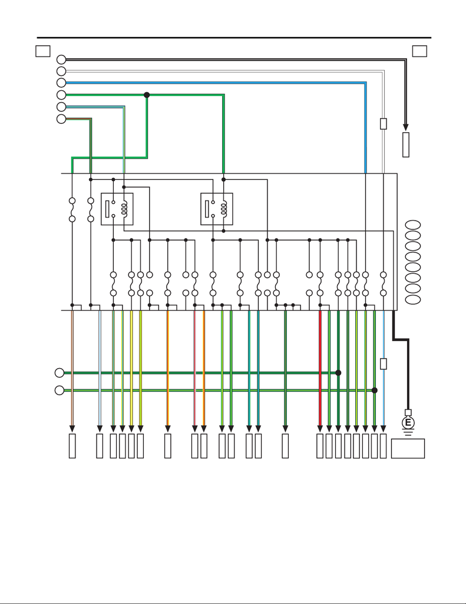

WI-40

Power Supply Circuit

WIRING SYSTEM

WI-44256

2f 2f

G/R

G

L/Y

E5

E8

F7

G

F8

F3

A19

W/L C19

A

F/B

i5

A:

R168

B:

B52

C:

B152

D:

B158

E:

B159

F:

B162

G:

AB35

H:

L

G/B

C11

G2G/Y

G/O

G/O

A3

D8

G/Y

D3

C1

N

D6

Y/G

A17Y/R

A1GR/R

Y/W B14

Y/L

G/Y C8

G/L

D9

C16G/L

G/R C24

B

B

L

F

G/R

B/W

L

G/B

G/O

G/Y B18

D7Y/R

G/R

D2

H2R

Q

F2

W

W

O

R

P

G

L/Y

ST-2

FB-38

FB-32

FB-28

FB-45

FB-18

FB-47

FB-43

FB-29

FB-31

FB-35

FB-34

FB-25

FB-20

A10Y/L

FB-19

A7BR/W

FB-12

FB-46

W/L D1

ST-1

FB-44

FB-42

FB-41

FB-22

FB-21

MTMT

No. 19

No. 32 7.5A

REF. TO GND

[b]

IG 2 RELAY

ACCESSORY RELAY

No. 6 7.5A

No. 2 7.5A

No. 13 20A

No. 22 10A

No. 21 7.5A

No. 33 7.5A

No. 26 7.5A

No. 25 15A

No. 12 15A

No. 5

No. 18 10A

No. 11 7.5A

No. 4 10A

No. 31 7.5A

No. 30

No. 24 10A

No. 23

No. 20 10A

No. 7 10A

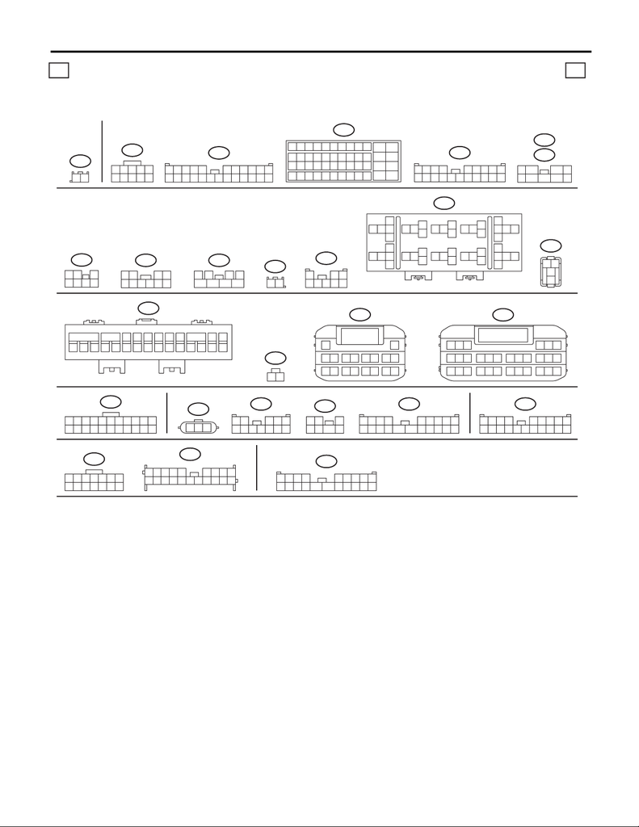

WI-41

Power Supply Circuit

WIRING SYSTEM

LIST OF CONNECTORS

RELAY HOLDER

FUSE HOLDER

AB35

B143

B575

B:

R168

A:

F37

B158

B571

i231

i150

G:

B:

i5

E:

F:

H:

F26

A:

B152

B426

B134A:

(B)

B186H:

B159F:

(BR)

B144D:

(BR)

(B)

B145

(L)

F35C:

B52C:

D:

(GR)

A:

B572

B162

G:

F36E:

(BR)

B23

WI-44257

12

10

12345

6789

3412 89

10 11

12 13 14 15 16 17 18 19 20 21 22 23 24

567

10

11 12

23 24

35 36

47 48

3

5

6

7894

12

45

4643 4441 4239 4037 38

21

2219 2017 1815 1613 14

33

3431 3229 3027 2825 26

89

19 20

1234 567

10 11 12 13 14 15 16 17 18

1

5

76

2

8

34

9

12 3

45

6

7

8765

21

10

9

43

1

7856

234

12

123

45678

1

2

3

4

11 12

34

13 14

56

15 16

78

17 18

10

9

12

21

123

456789

10 11

12 13 14 15 16 17 18 19 20 21 22

123

12

3

45

6789

10 11 12

12 3

4567

1234

56789

10 11 12 13 14 15 16 17 18 19 20

89

19 20

1234 567

10 11 12 13 14 15 16 17 18

3

42

156

7

13 1411

12

9

10

8

12345 6789

10 11 12 13 14 15 16 17 18 19 20

1234

56789

10 11 12 13 14 15 16 17 18 19 20

2g 2g

B225

10 11

12

13

14 15

16

18

19 21 22

20

17

24

5

3

17

9

8

6

32 33

34

35

28262423

25

27

29

30

31

36 37

38

40

41 43 44

42

39

91

2

232221 262524201918

4

13

12

17

3

16

6

15

587

14

10 11

B550

(B)

B574C:

19 20 21 22 23 24 25 26 27 28 29 30

789

10 11 12 13 14 15 16 17 18

123 456

[figure not shown]

WI-42

Power Supply Circuit

WIRING SYSTEM

No. Load

MB-1 VDC CM

MB-2 VDC CM

MB-3 Audio amplifier

MB-4 Sub fan relay

MB-5 Mirror heater LH

Mirror heater RH

Rear defogger

MB-6 Body integrated unit

MB-7 Main fan relay 2

MB-8 Main fan motor

MB-9 ECM

MB-10 Main fan relay 2

MB-11 Main fan relay 2

MB-12 Body integrated unit

MB-13 Body integrated unit

MB-15 Front fog light relay

MB-16 Front combination light LH

Front combination light RH

MB-17 Daytime running light relay

MB-18 Body integrated unit

MB-19 Horn

MB-20 Horn

MB-21 Horn switch

Body integrated unit

MB-22 A/F, oxygen sensor relay

Fuel injector relay

MB-23 Main relay

IG relay

MB-24 Electronic throttle control relay

MB-25 Fuel pump relay

MB-26 TCM

Self shut relay

MB-27 ECM

Battery sensor

Data link connector

MB-28 Turn signal and hazard unit

Body integrated unit

MB-29 Room light

Overhead console (spot map light)

Stereo camera cover (spot map light)

Body integrated unit

Remote engine start CM

MB-30 Power window circuit breaker

MB-31 Accessory relay

IG relay 1

IG relay 2

MB-32 Tail & Illumination relay

Daytime running light relay

MB-33 Wiper relay

Brake pump relay

MB-35 Keyless access CM

ID code box

ALT-2 ECM

ST-1 Clutch start switch

ST-2 Starter relay 1

FB-3 Stop light and brake switch

FB-4 Wiper deicer relay

FB-5 Seat heater relay

FB-6 Body integrated unit

FB-8 Blower motor relay

FB-9 Front fog light relay

FB-10 Navigation unit

MFD

Audio

FB-11 Trunk room light

FB-12 MFD

Combination meter

FB-18 Impact sensor

Combination meter

Air mix door actuator LH

Air mix door actuator RH

Mode door actuator

Steering lock CM

Body integrated unit

FB-19 Remote control mirror switch

FB-20 Seat heater relay

Rear view mirror

FB-21 Rear accessory power supply socket

FB-22 Front accessory power supply socket

FB-25 Audio

Navigation unit

FB-28 A/C control panel

FB-29 Body integrated unit

FB-31 TPMS CM

FB-32 Sunroof switch

Sunroof unit

Data link connector

Stop light and brake switch

Wiper deicer relay

Impact sensor

Clutch switch

Remote engine start CM

FB-34 Turn signal and hazard unit

FB-35 Inhibitor switch

Back-up light switch

Auto headlight beam leveler CM

No. Load

[figure not shown]

WI-43

Power Supply Circuit

WIRING SYSTEM

FB-38 ECM

TCM

Body integrated unit

Fuel pump relay

Keyless access CM

FB-41 Airbag CM

FB-42 Power window relay

Wiper relay

FB-43 Steering lock CM

FB-44 VDC CM

Steering angle sensor

Power steering CM

FB-45 A/C control panel

FB-46 A/C relay

Sub fan relay

Pressure switch

Blower motor relay

FB-47 Occupant detection control module

BAT-1 Power steering CM

No. Load

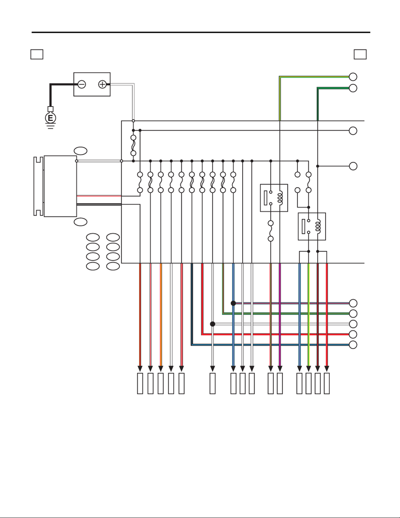

WI-44

Power Supply Circuit

WIRING SYSTEM

3. ENGINE TYPE EJ (WITHOUT PUSH BUTTON START)

WI-44258

3a 3a

F26

F25

W

B

W

B143

B:

F36

E:

F70

F:

B186

H:

Y/G

BR/R

B/R

W/R

B/W

2

1

B7

C10

M/B

B

A

C

I

H

D

A7

A9

L/R E5

E6

R/G G7

H8

G/O

G/B

H4

B19

G

F

E

F37

A:

F35

C:

B144

D:

B145

G:

L/R D9

WF2

G/R D3

WD2

RD6

R/W E3

R/Y D5

W/R D7

B11

B/L D8

R

V

G/O

G/B

L/R

G/R

W

R

B/L

WD1

WF1

MB-34

MB-31

MB-3

MB-5

MB-6

MB-7

MB-8

MB-9

MB-1

MB-33

MB-4

MB-10

MB-2

ALT-1

MB-29

SBF-2 50A

SBF-3 50A

SBF-6 50A

SBF-8 50A

SBF-1 40A

No. 4

MAIN SBF 120A

REAR DEFOGGER RELAY

MAIN FAN RELAY 1

No. 10 25A

No. 16 7.5A

No. 1 30A

No. 5 25A

No. 3 25A

No. 8 20A

No. 2 25A

BATTERY

GENERATOR

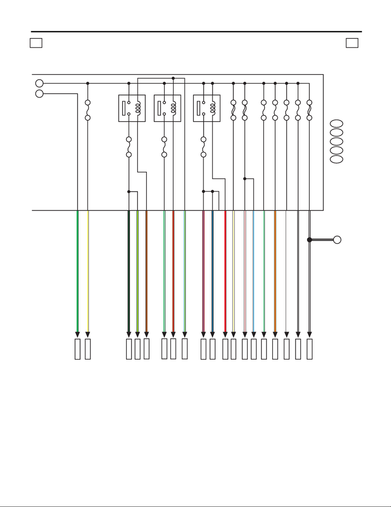

WI-45

Power Supply Circuit

WIRING SYSTEM

WI-44259

3b 3b

B143

F35

F36

B145

B186

W/B H6

WH5

G4

M/B

B/W

W/G H3

W/L G6

W/Y G1

G5W/R

B:

C:

E:

G:

H:

RH1

C9

C8

B16

G/W E1

G/Y E4

B18

W/Y G2

C11

C

D

J

G

BR/R

B15L/Y

BR

R/L

B/L

B/W

Y/R H7

SBF-4 30A

SBF-5 30A

MB-26

MB-13

MB-30

MB-12

MB-19

MB-16

B/G B8

MB-15

MB-17

MB-18

MB-23

MB-20

MB-28

MB-32

MB-27

MB-24

MB-25

MB-22

MB-11

MB-21

SBF-7 30A

HORN RELAY

HEADLIGHT RELAY HI

HEADLIGHT RELAY LO

No. 9 15A

No. 7 15A

No. 6 30A

No. 15 15A

No. 11 15A

No. 12 10A

No. 13 7.5A

No. 14 15A

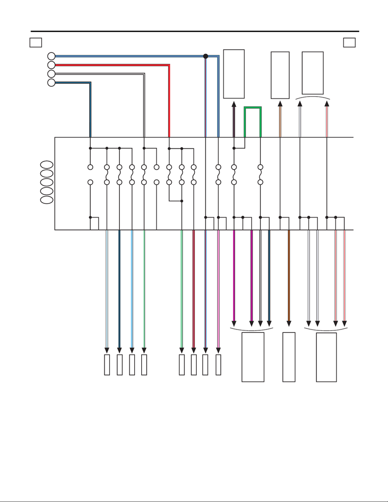

WI-46

Power Supply Circuit

WIRING SYSTEM

WI-44260

3c 3c

B/W

B12

C17

B/L

V

V

A11

C5

R/L C2

G/W

F1

B/L

B/W

E6

E4

R

F6

G

C20

C21

E7

W/G

A9

L/W

C15

L/B

E3

W/L

E1

E

H

J

I

F/B

i5

A:

R168

B:

B52

C:

B158

E:

B159

F:

G

L/R

E2

L/R

C4

B/P

B15

BR

BR/W

F9

A12

GR

GR

C18

B3

GR

A18

W/R

A4

L/R

B2

P

W/R

C9

L/R

R

B/W

B/L

B20

W/R

FB-3

FB-11

FB-10

FB-9

FB-8

FB-6

FB-5

FB-4

REF. TO

TURN SIGNAL LIGHT

& HAZARD LIGHT

SYSTEM [b]

No. 15 10A

No. 14 10A

No. 16 7.5A

No. 17 15A

No. 29 15A

No. 28 15A

No. 27 15A

No. 10

No. 9 7.5A

No. 8 7.5A

No. 1

No. 3 15A

REF. TO TURN SIGNAL

LIGHT & HAZARD LIGHT

SYSTEM [b]

REF. TO STOP LIGHT

SYSTEM

[2a]

REF. TO CLEARANCE

LIGHT & ILLUMINATION

LIGHT SYSTEM [2a]

REF. TO CLEARANCE

LIGHT & ILLUMINATION

LIGHT SYSTEM [2a]

REF. TO STOP LIGHT

SYSTEM [2a]

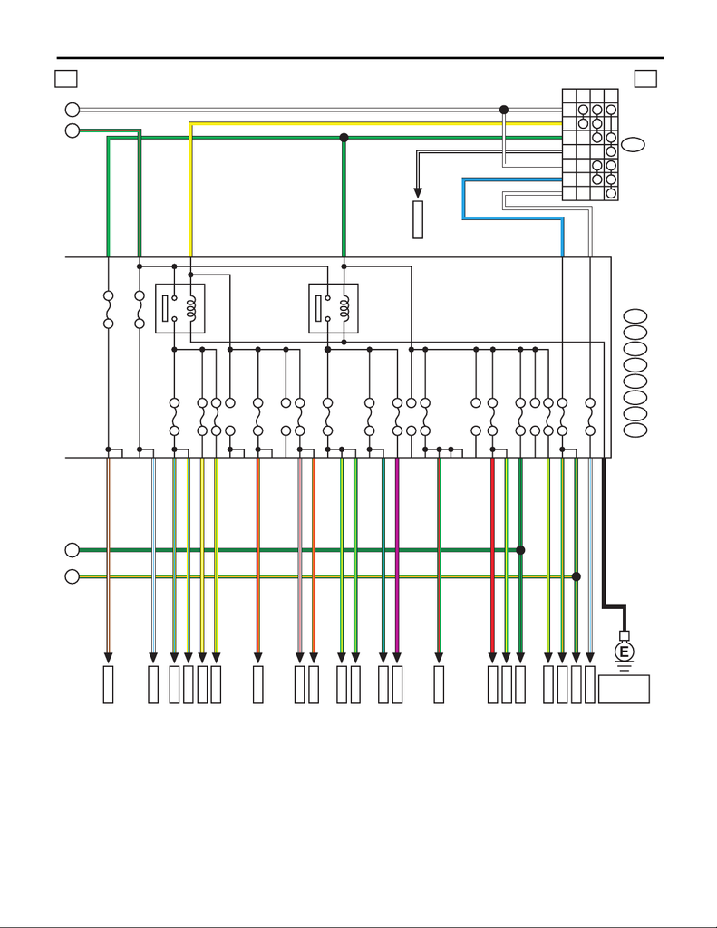

WI-47

Power Supply Circuit

WIRING SYSTEM

WI-44261

B72

B

3d 3d

G/R

G

Y

E5

E8

F7

GF8

F3

A19

A7

W/L C19

G

F

A

F/B

i5

A:

R168

B:

B52

C:

B152

D:

B158

E:

B159

F:

B162

G:

L

F2 W

G/B C11

G2G/Y

W/L D1

G/O

G/O

A3

D8

G/Y D3

C1

D6

BR/W

Y/G

A17Y/R

A1GR/R

D7Y/R

Y/W B14

Y/L

G/Y

C8

G/L D9

C16V

G/R C24

B

4

2

1

W

L

W

3

5

6

7

ACCOFF

ON ST

W

B/W

Y

G

B

G/B

G/O

G/R

W

H2R

G/Y

B18

AB35

H:

FB-31

FB-47

FB-35

FB-34

FB-29

FB-25

FB-20

A10Y/L

FB-19

FB-46

FB-44

FB-42

FB-41

FB-22

FB-21

FB-12

ST-2

FB-38

FB-32

FB-28

ST-1

FB-45

FB-18

No. 19

No. 32

REF. TO GND

[b]

IG 2 RELAY

ACCESSORY RELAY

IGNITION SWITCH

No. 6 7.5A

No. 13 20A

No. 21 7.5A

No. 22 10A

No. 33 7.5A

No. 26 7.5A

No. 25 15A

No. 12 15A

No. 5

No. 18 10A

No. 11 7.5A

No. 4 10A

No. 31 7.5A

No. 30

No. 24 10A

No. 23

No. 20 10A

No. 7 10A

No. 2 7.5A

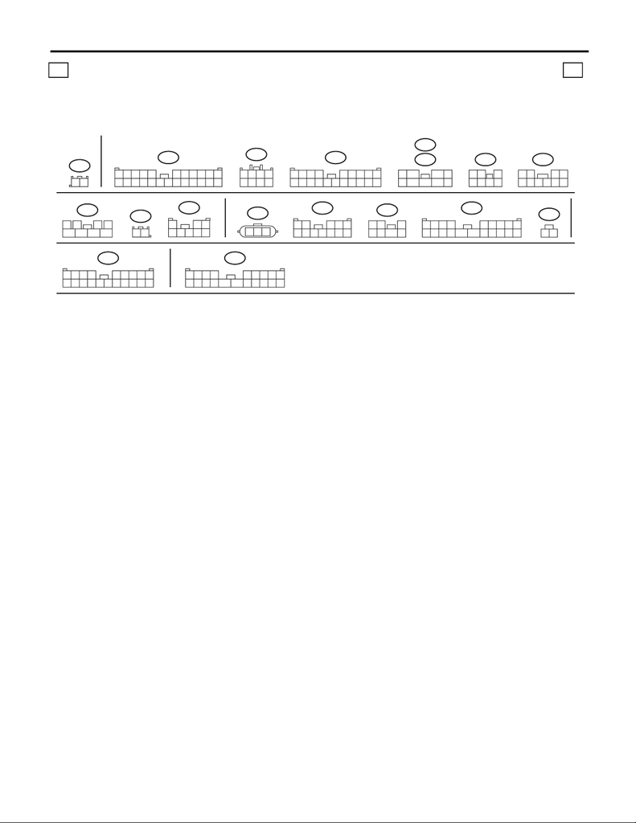

WI-48

Power Supply Circuit

WIRING SYSTEM

LIST OF CONNECTORS

3e 3e

AB35

A:

F37

F:

F70

B143

B:

R168

G:

B:

i5

B158

E:

H:

F26

A:

B152

(B)

B186H:

B159F:

(BR)

B144D:

F36E:

(BR)

B145

(L)

F35C:

B52C:

D:

(GR)

B162

G:

12

3412 89

10 11

12 13 14 15 16 17 18 19 20 21 22 23 24

567

89

19 20

1234 567

10 11 12 13 14 15 16 17 18

1

5

76

2

8

34

9

12 3

45

6

78765

21

10

9

43

1

7856

234

12

123

45678

123

12

3

45

6789

10 11 12

12 3

4567

1234

56789

10 11 12 13 14 15 16 17 18 19 20

12

89

19 20

1234 567

10 11 12 13 14 15 16 17 18

1234

56789

10 11 12 13 14 15 16 17 18 19 20

WI-44262

B72

7856

341

2

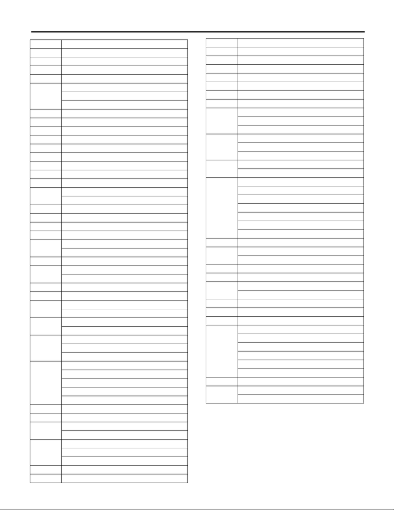

WI-49

Power Supply Circuit

WIRING SYSTEM

No. Load

MB-1 VDC CM

MB-2 VDC CM

MB-3 Audio amplifier

MB-4 Sub fan relay

MB-5 Mirror heater LH

Mirror heater RH

Rear defogger

MB-6 Body integrated unit

MB-7 Main fan relay 2

MB-8 Main fan motor

MB-9 ECM

MB-10 Main fan relay 2

MB-11 Main fan relay 2

MB-12 Body integrated unit

MB-13 Body integrated unit

MB-15 Front fog light relay

MB-16 Front combination light LH

Front combination light RH

MB-17 Daytime running light relay

MB-18 Body integrated unit

MB-19 Horn

MB-20 Horn

MB-21 Horn switch

Body integrated unit

MB-22 A/F, oxygen sensor relay

MB-23 Main relay

A/F, oxygen sensor relay

MB-24 Electronic throttle control relay

MB-25 Fuel pump relay

MB-26 DCCD CM

DCCD relay

MB-27 ECM

Data link connector

MB-28 Turn signal and hazard unit

Body integrated unit

Key warning switch

MB-29 Body integrated unit

Immobilizer antenna

Room light

Overhead console (spot map light)

Stereo camera cover (spot map light)

MB-30 Power window circuit breaker

MB-31 Wiper relay

MB-32 Tail & Illumination relay

Daytime running light relay

MB-33 Secondary air combination valve relay 1

Secondary air combination valve relay 2

Brake pump relay

MB-34 Secondary air pump relay

ST-1 Clutch start switch

ST-2 Starter relay 1

FB-3 Stop light and brake switch

FB-4 Wiper deicer relay

FB-5 Seat heater relay

FB-6 Body integrated unit

FB-8 Blower motor relay

FB-9 Front fog light relay

FB-10 Navigation unit

MFD

Audio

FB-11 Trunk room light

TPMS & keyless entry CM

Keyless entry CM

FB-12 MFD

Combination meter

FB-18 Security CM

Combination meter

Impact sensor

Air mix door actuator LH

Air mix door actuator RH

Mode door actuator

Body integrated unit

FB-19 Remote control mirror switch

FB-20 Seat heater relay

Rear view mirror

FB-21 Rear accessory power supply socket

FB-22 Front accessory power supply socket

FB-25 Audio

Navigation unit

FB-28 A/C control panel

FB-29 Body integrated unit

FB-31 TPMS & keyless entry CM

FB-32 Sunroof switch

Clutch switch

Sunroof unit

Data link connector

Stop light and brake switch

Wiper deicer relay

FB-34 Turn signal and hazard unit

FB-35 Back-up light switch

Auto headlight beam leveler CM

No. Load

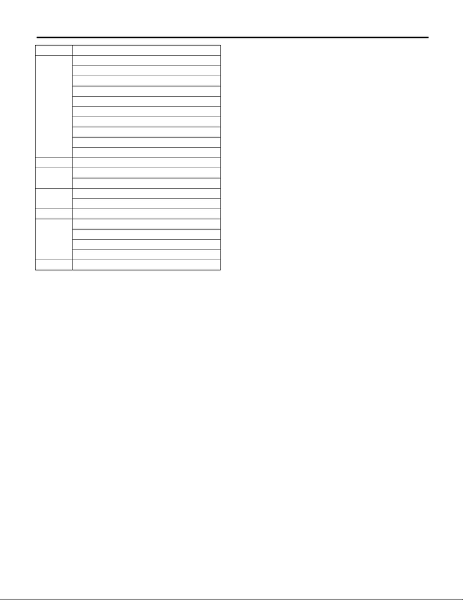

WI-50

Power Supply Circuit

WIRING SYSTEM

FB-38 ECM

Body integrated unit

Fuel pump relay

Keyless access CM

Ignition coil No. 1

Ignition coil No. 2

Ignition coil No. 3

Ignition coil No. 4

DCCD CM

DCCD relay

FB-41 Airbag CM

FB-42 Power window relay

Wiper relay

FB-44 VDC CM

Steering angle sensor

FB-45 A/C control panel

FB-46 A/C relay

Sub fan relay

Pressure switch

Blower motor relay

FB-47 Occupant detection control module

No. Load

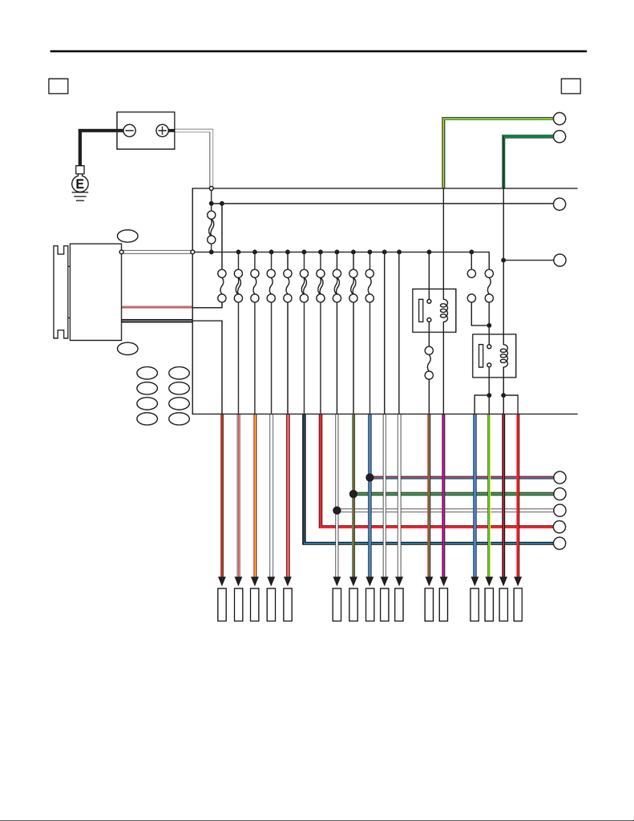

WI-51

Power Supply Circuit

WIRING SYSTEM

4. ENGINE TYPE EJ (WITH PUSH BUTTON START)

WI-44263

4a 4a

F26

F25

W

B

W

B143

B:

F36

E:

F70

F:

B186

H:

Y/G

BR/R

B/R

W/R

B/W

2

1

B7

C10

M/B

B

A

C

I

H

D

A7

A9

L/R E5

E6

R/G G7

H8

G/O

G/B

H4

B19

G

F

E

F37

A:

F35

C:

B144

D:

B145

G:

L/R D9

WF2

G/R D3

WD2

RD6

R/W E3

R/Y D5

W/R D7

B11

B/L D8

R

V

G/O

G/B

L/R

G/R

W

R

B/L

WD1

WF1

SBF-2 50A

SBF-3 50A

SBF-6 50A

SBF-8 50A

SBF-1 40A

MB-35

ALT-1

MB-29

MB-34

MB-31

MB-3

MB-5

MB-6

MB-7

MB-8

MB-9

MB-1

MB-33

MB-4

MB-10

MB-2

No. 4

REAR DEFOGGER RELAY

MAIN FAN RELAY 1

No. 10 25A

No. 16 7.5A

No. 1 30A

No. 5 25A

No. 3 25A

No. 8 20A

No. 2 25A

BATTERY

GENERATOR

MAIN SBF 120A

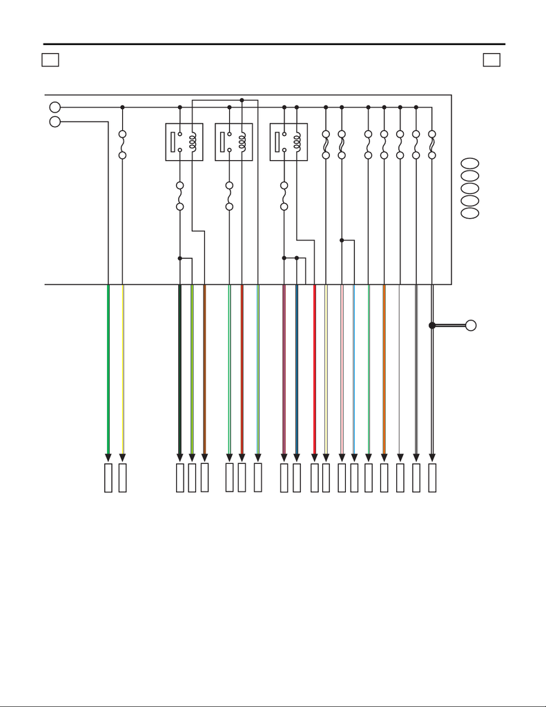

WI-52

Power Supply Circuit

WIRING SYSTEM

WI-44264

4b 4b

B143

F35

F36

B145

B186

W/B H6

WH5

G4

M/B

B/W

W/G H3

W/L G6

W/Y G1

G5W/R

B:

C:

E:

G:

H:

RH1

C9

C8

B16

G/W E1

G/Y E4

B18

W/Y G2

C11

C

D

J

G

BR/R

B15L/Y

BR

R/L

B/L

B/W

Y/R H7

SBF-5 30A

SBF-7 30A

MB-26

MB-13

MB-30

MB-12

MB-19

MB-16

B/G B8

MB-15

MB-17

MB-18

MB-23

MB-20

MB-28

MB-32

MB-27

MB-24

MB-25

MB-22

MB-11

MB-21

SBF-4 30A

HORN RELAY

HEADLIGHT RELAY HI

HEADLIGHT RELAY LO

No. 9 15A

No. 7 15A

No. 6 30A

No. 15 15A

No. 11 15A

No. 12 10A

No. 13 7.5A

No. 14 15A

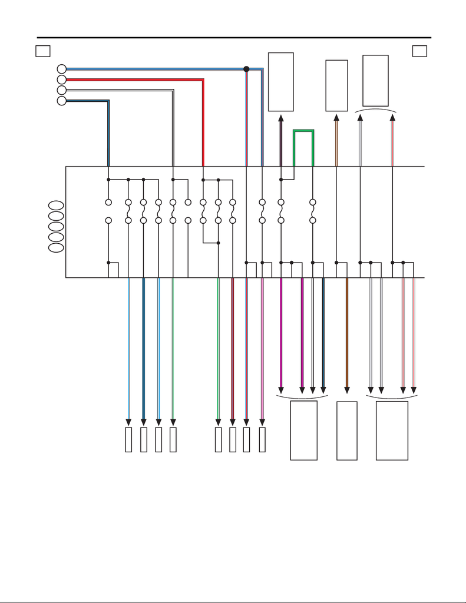

WI-53

Power Supply Circuit

WIRING SYSTEM

WI-44265

4c 4c

B/W

B12

C17

B/L

V

V

A11

C5

R/L C2

G/W

F1

B/L

B/W

E6

E4

R

F6

G

C20

C21

E7

W/G

A9

L/W

C15

L/B

E3

W/L

E1

E

H

J

I

F/B

i5

A:

R168

B:

B52

C:

B158

E:

B159

F:

G

L/R

E2

L/R

C4

B/P

B15

BR

BR/W

F9

A12

GR

GR

C18

B3

GR

A18

W/R

A4

L/R

B2

P

W/R

C9

L/R

R

B/W

B/L

B20

W/R

FB-9

FB-10

FB-11

FB-8

FB-6

FB-5

FB-4

FB-3

REF. TO

TURN SIGNAL LIGHT

& HAZARD LIGHT

SYSTEM [b]

No. 15 10A

No. 14 10A

No. 16 7.5A

No. 17 15A

No. 29 15A

No. 28 15A

No. 27 15A

No. 10

No. 9 7.5A

No. 8 7.5A

No. 1

No. 3 15A

REF. TO TURN SIGNAL

LIGHT & HAZARD LIGHT

SYSTEM [b]

REF. TO STOP LIGHT

SYSTEM[2a]

REF. TO CLEARANCE

LIGHT & ILLUMINATION

LIGHT SYSTEM [2a]

REF. TO CLEARANCE

LIGHT & ILLUMINATION

LIGHT SYSTEM [2a]

REF. TO STOP LIGHT

SYSTEM [2a]

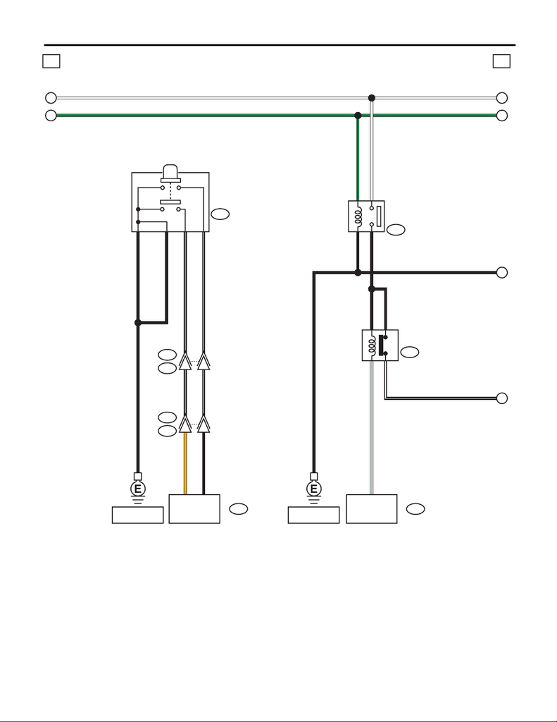

WI-54

Power Supply Circuit

WIRING SYSTEM

B

B

B225

B225

WI-44266

i150

20

19

4d 4d

W

W

G

K

G/B

G/B

B

L

N

BB

B/W

M

G/B30

W29

B42

B44

31B

2B/O

7B/W

4B

5B

28B40W/R

41B/W

BC30

OC28

B34

B135B:

W/R

B553

i231

16

17

B576

B575

B574

C:

B/O

B/O

B/W

B/W

ECM

REF. TO GND

[b] [d]

KEYLESS ACCESS CM

REF. TO GND

[e]

PUSH BUTTON

IGNITION SWITCH

STARTER CUT

RELAY

STARTER RELAY

(PUSH BUTTON START)

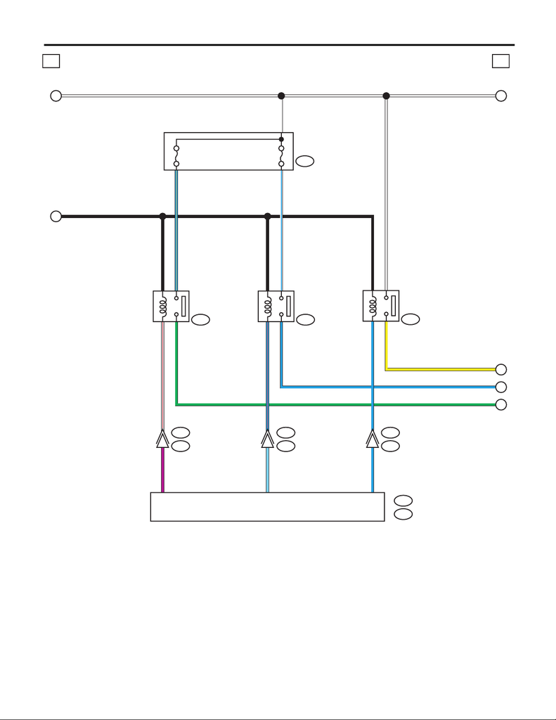

WI-55

Power Supply Circuit

WIRING SYSTEM

B225B225

B426

WI-44267

3

11

5

20A

B550

4e 4e

W

K

B

M

Y

P

B35

W/L33

34L/R

L

24L/O

25W/L

32

B39

L/O37

38GR/R

36G

B2

W3

1L

L/R

GR/R

L

4Y

Q

G

L

R

B572

A:

B574

C:

L

SB

V

C4

A9

C6

B28

B23

B576

B575

B28

B23

15A

W10

W

O

KEYLESS ACCESS CM

FUSE HOLDER

ACCESSORY RELAY

(PUSH BUTTON

START)

IG RELAY 1

(PUSH BUTTON

START)

IG RELAY 2

(PUSH BUTTON

START)

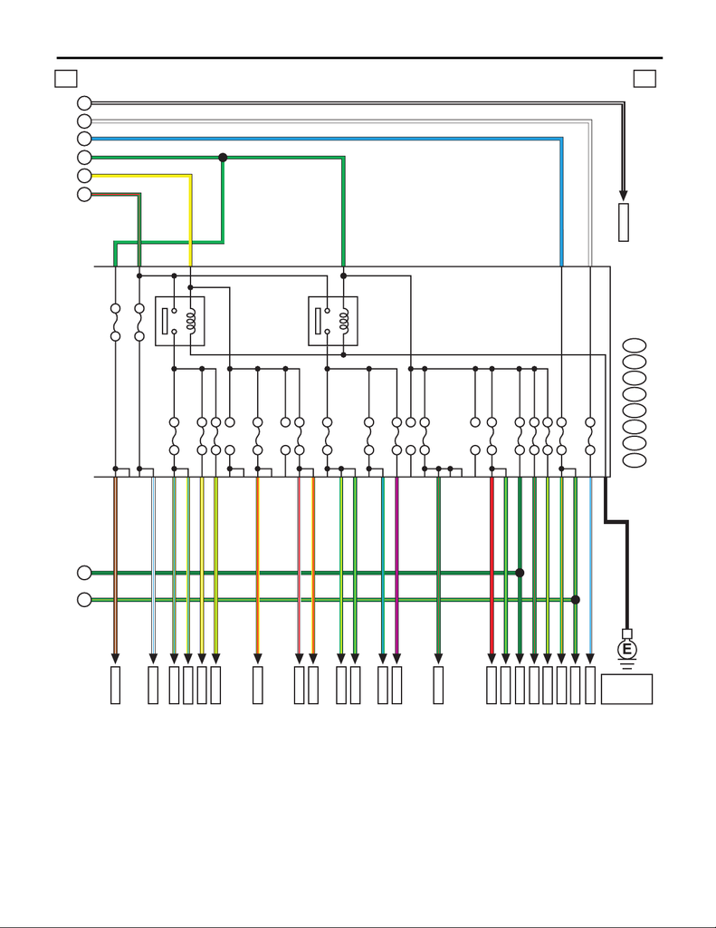

WI-56

Power Supply Circuit

WIRING SYSTEM

WI-44268

4f 4f

G/R

Y

E5

G

E8

F7

G

F8

F3

A19

W/L C19

A

F/B

i5

A:

R168

B:

B52

C:

B152

D:

B158

E:

B159

F:

B162

G:

AB35

H:

L

G/B

C11

G2G/Y

G/O

G/O

A3

D8

G/Y

D3

C1

N

D6

Y/G

A17Y/R

A1GR/R

Y/W B14

Y/L

G/Y C8

G/L

D9

C16V

G/R C24

B

B

L

F

G/R

B/W

L

G/B

G/O

G/Y B18

D7Y/R

G/R

D2

H2R

Q

F2

W

W

O

R

P

G

Y

ST-2

FB-38

FB-32

FB-28

FB-45

FB-18

BR/W A7

FB-12

FB-47

FB-43

FB-29

FB-31

W/L D1

ST-1

FB-35

FB-34

FB-25

FB-20

A10Y/L

FB-19

FB-46

FB-44

FB-42

FB-41

FB-22

FB-21

No. 19

No. 32 7.5A

REF. TO GND

[b]

IG 2 RELAY

ACCESSORY RELAY

No. 6 7.5A

No. 13 20A

No. 22 10A

No. 33 7.5A

No. 26 7.5A

No. 25 15A

No. 12 15A

No. 5

No. 21 7.5A

No. 18 10A

No. 11 7.5A

No. 4 10A

No. 31 7.5A

No. 30

No. 24 10A

No. 23

No. 20 10A

No. 7 10A

No. 2 7.5A

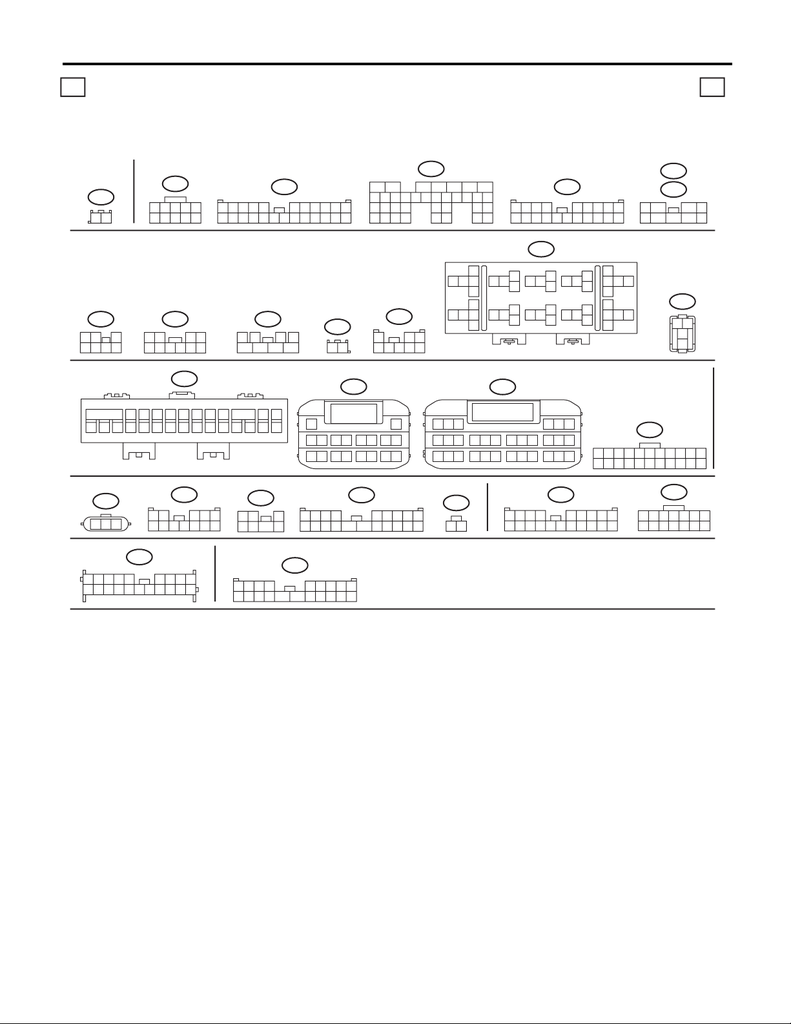

WI-57

Power Supply Circuit

WIRING SYSTEM

LIST OF CONNECTORS

RELAY HOLDER

FUSE HOLDER

4g 4g

AB35

B143

B575

B:

R168

A:

F37

F:

F70

B158

i231

G:

B:

i5

B135

B:

B225

E:

H:

F26

A:

B152

B426

B550

(B)

(B)

B186H:

B159F:

(BR)

B144D:

(BR)

B145

(L)

F35C:

B52

B23

C:

D:

(GR)

A:

B572

B162

G:

F36E:

12

10

12345

6789

3412 89

10 11

12 13 14 15 16 17 18 19 20 21 22 23 24

567

5672134

29

10 11 12 13 14 15

2524

16

30

98

17 18 19

20

28

21 22 23

3231

26 27

33 34 35

89

19 20

1234 567

10 11 12 13 14 15 16 17 18

1

5

76

2

8

34

9

12 3

45

6

78765

21

10

9

43

1

7856

234

12

123

45678

10 11

12

13

14 15

16

18

19 21 22

20

17

24

5

3

17

9

8

6

32 33

34

35

28262423

25

27

29

30

31

36 37

38

40

41 43 44

42

39

1

2

3

4

101

242322 272625212019

5

14

13

18

432

17

7

16

698

15

11 12

11 12

34

13 14

56

15 16

78

17 18

10

9

12

123

456789

10 11

12 13 14 15 16 17 18 19 20 21 22

123

12

3

45

6789

10 11 12

12 3

4567

1234

56789

10 11 12 13 14 15 16 17 18 19 20

12

89

19 20

1234 567

10 11 12 13 14 15 16 17 18

12345 6789

10 11 12 13 14 15 16 17 18 19 20

1234

56789

10 11 12 13 14 15 16 17 18 19 20

(B)

WI-44269

i150

3

42

156

7

13 1411

12

9

10

8

B574C:

19 20 21 22 23 24 25 26 27 28 29 30

789

10 11 12 13 14 15 16 17 18

123 456

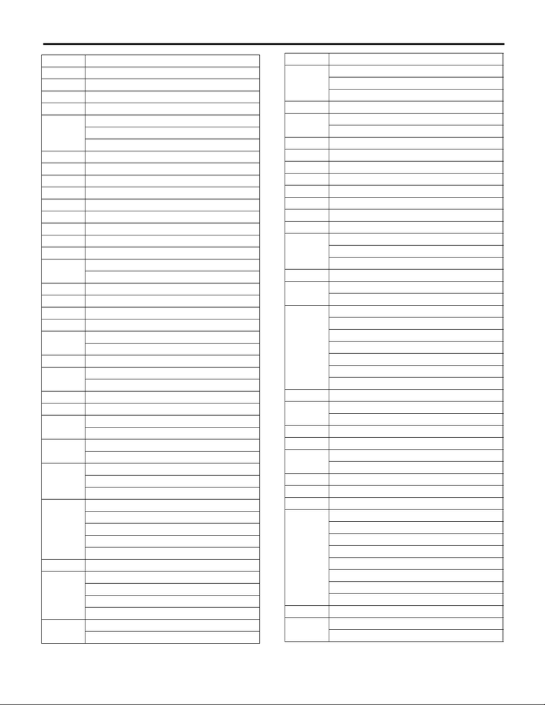

WI-58

Power Supply Circuit

WIRING SYSTEM

No. Load

MB-1 VDC CM

MB-2 VDC CM

MB-3 Audio amplifier

MB-4 Sub fan relay

MB-5 Mirror heater LH

Mirror heater RH

Rear defogger

MB-6 Body integrated unit

MB-7 Main fan relay 2

MB-8 Main fan motor

MB-9 ECM

MB-10 Main fan relay 2

MB-11 Main fan relay 2

MB-12 Body integrated unit

MB-13 Body integrated unit

MB-15 Front fog light relay

MB-16 Front combination light LH

Front combination light RH

MB-17 Daytime running light relay

MB-18 Body integrated unit

MB-19 Horn

MB-20 Horn

MB-21 Horn switch

Body integrated unit

MB-22 A/F, oxygen sensor relay

MB-23 Main relay

A/F, oxygen sensor relay

MB-24 Electronic throttle control relay

MB-25 Fuel pump relay

MB-26 DCCD CM

DCCD relay

MB-27 ECM

Data link connector

MB-28 Key warning switch

Turn signal and hazard unit

Body integrated unit

MB-29 Body integrated unit

Remote engine start CM

Room light

Overhead console (spot map light)

Stereo camera cover (spot map light)

MB-30 Power window circuit breaker

MB-31 Wiper relay

Accessory relay

IG relay 1

IG relay 2

MB-32 Tail & Illumination relay

Daytime running light relay

MB-33 Secondary air combination valve relay 1

Secondary air combination valve relay 2

Brake pump relay

MB-34 Secondary air pump relay

MB-35 ID code box

Keyless access CM

ST-1 Clutch start switch

ST-2 Starter relay 1

FB-3 Stop light and brake switch

FB-4 Wiper deicer relay

FB-5 Seat heater relay

FB-6 Body integrated unit

FB-8 Blower motor relay

FB-9 Front fog light relay

FB-10 Navigation unit

MFD

Audio

FB-11 Trunk room light

FB-12 MFD

Combination meter

FB-18 Impact sensor

Combination meter

Air mix door actuator LH

Air mix door actuator RH

Mode door actuator

Body integrated unit

Steering lock CM

FB-19 Remote control mirror switch

FB-20 Seat heater relay

Rear view mirror

FB-21 Rear accessory power supply socket

FB-22 Front accessory power supply socket

FB-25 Audio

Navigation unit

FB-28 A/C control panel

FB-29 Body integrated unit

FB-31 TPMS CM

FB-32 Sunroof switch

Clutch switch

Sunroof unit

Data link connector

Stop light and brake switch

Wiper deicer relay

Impact sensor

Remote engine start CM

FB-34 Turn signal and hazard unit

FB-35 Back-up light switch

Auto headlight beam leveler CM

No. Load

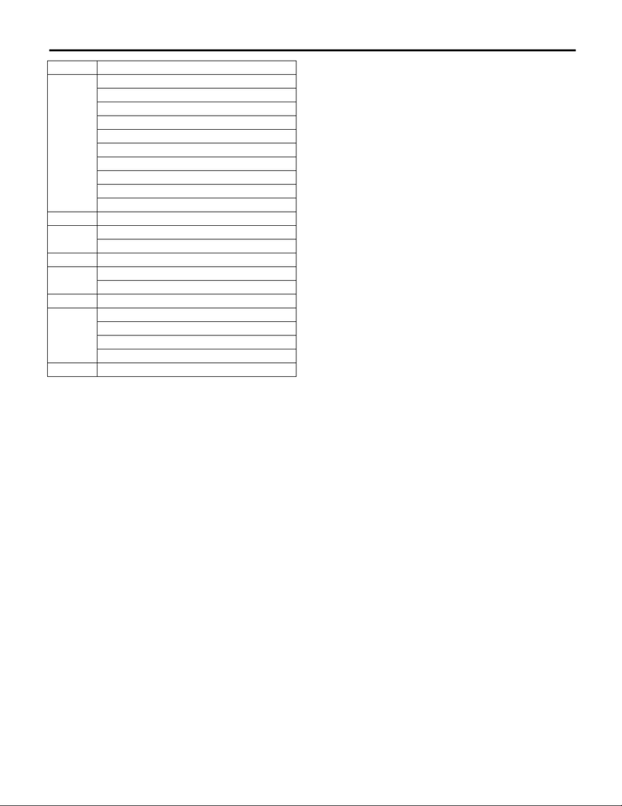

WI-59

Power Supply Circuit

WIRING SYSTEM

FB-38 ECM

Body integrated unit

Fuel pump relay

Keyless access CM

Ignition coil No. 1

Ignition coil No. 2

Ignition coil No. 3

Ignition coil No. 4

DCCD CM

DCCD relay

FB-41 Airbag CM

FB-42 Power window relay

Wiper relay

FB-43 Steering lock CM

FB-44 VDC CM

Steering angle sensor

FB-45 A/C control panel

FB-46 A/C relay

Sub fan relay

Pressure switch

Blower motor relay

FB-47 Occupant detection control module

No. Load